# IE6600 Team Project

## HYGIENE

Definition: Hygiene refers to the conditions and practices that help maintain health and prevent spread of disease including handwashing, food hygiene, and menstrual hygiene management (https://washdata.org/monitoring/hygiene).

```r
hygiene_raw <- read_excel(file_path, sheet = "Hygiene") #.name_repair = "universal")

hygiene_raw
```

### Rename columns

```r
#rename column names
hygiene <- read_excel(file_path, sheet = "Hygiene")
#tidying
hygiene <- hygiene[-c(1),] #remove 2nd row (1st row in R)

column_names_hygiene <- c(
  "COUNTRY",
  "ISO3",
  "YEAR",
  "POPULATION(THOUSANDS)",
  "%URBAN",
  "NATIONAL_AtLeastBasic",
  "NATIONAL_Limited(withoutWaterOrSoap)",
  "NATIONAL_NoFacility",
  "NATIONAL_AnnualRateOfChangeInBasic",
  "RURAL_AtLeastBasic",
  "RURAL_Limited(withoutWaterOrSoap)",
  "RURAL_NoFacility",
  "RURAL_AnnualRateOfChangeInBasic",
  "URBAN_AtLeastBasic",
  "URBAN_Limited(withoutWaterOrSoap)",
  "URBAN_NoFacility",
  "URBAN_AnnualRateOfChangeInBasic",
  "SI",
  "SDGRegion",
  "WHORegion",
  "UNICEFProgrammingRegion",
  "UNICEFReportingRegion"
)

hygiene <- hygiene %>% rename_with(~column_names_hygiene)

sapply(hygiene, class)
```

```
                             COUNTRY                                 ISO3                                 YEAR
                         "character"                          "character"                            "numeric"
               POPULATION(THOUSANDS)                               %URBAN                NATIONAL_AtLeastBasic
                           "numeric"                            "numeric"                          "character"
NATIONAL_Limited(withoutWaterOrSoap)                  NATIONAL_NoFacility   NATIONAL_AnnualRateOfChangeInBasic
                         "character"                          "character"                          "character"
                  RURAL_AtLeastBasic    RURAL_Limited(withoutWaterOrSoap)                     RURAL_NoFacility
                         "character"                          "character"                          "character"
     RURAL_AnnualRateOfChangeInBasic                   URBAN_AtLeastBasic    URBAN_Limited(withoutWaterOrSoap)
                         "character"                          "character"                          "character"
                    URBAN_NoFacility      URBAN_AnnualRateOfChangeInBasic                                   SI
                         "character"                          "character"                          "character"
                           SDGRegion                            WHORegion              UNICEFProgrammingRegion
                         "character"                          "character"                          "character"
               UNICEFReportingRegion
                         "character"
```

###Tidying Data

```r
hygiene <- hygiene %>% dplyr::select(-SI) #remove indexing

#replace "-" with NA
hygiene <- hygiene %>% mutate_all(~ifelse(. == "-", NA, .))

#head(hygiene)
```

### Set as numeric

```r
#clean non numeric
# For now, "<1" is replaced with 0.5, and ">99" is replaced with 99.5
hygiene <- hygiene %>% mutate_all(~ifelse(. == "<1", 0.5, .))
hygiene <- hygiene %>% mutate_all(~ifelse(. == ">99", 99.5, .))

hygiene <- hygiene %>%
  mutate_at(6:17, as.numeric)

sapply(hygiene, class)
```

```
                             COUNTRY                                 ISO3                                 YEAR
                         "character"                          "character"                            "numeric"
               POPULATION(THOUSANDS)                               %URBAN                NATIONAL_AtLeastBasic
                           "numeric"                            "numeric"                            "numeric"
NATIONAL_Limited(withoutWaterOrSoap)                  NATIONAL_NoFacility   NATIONAL_AnnualRateOfChangeInBasic
                           "numeric"                            "numeric"                            "numeric"
                  RURAL_AtLeastBasic    RURAL_Limited(withoutWaterOrSoap)                     RURAL_NoFacility
                           "numeric"                            "numeric"                            "numeric"
     RURAL_AnnualRateOfChangeInBasic                   URBAN_AtLeastBasic    URBAN_Limited(withoutWaterOrSoap)
                           "numeric"                            "numeric"                            "numeric"
                    URBAN_NoFacility      URBAN_AnnualRateOfChangeInBasic                            SDGRegion
                           "numeric"                            "numeric"                          "character"
                           WHORegion              UNICEFProgrammingRegion                UNICEFReportingRegion
                         "character"                          "character"                          "character"
```

### Pivot Longer

```r
#Make dataset from wide to long, see R documentation (example shown below)
hygiene1 <- hygiene %>%
  pivot_longer(
    cols = NATIONAL_AtLeastBasic:URBAN_AnnualRateOfChangeInBasic,
    names_to = c("REGION", "ServiceLevel"),
    names_sep = "_",
    values_to = "Percentage")

head(hygiene1)
```

| COUNTRY | ISO3 | YEAR | POPULATION(THOUSANDS) | %URBAN | SDGRegion | WHORegion | UNICEFProgrammingRegion | UNICEFReportingRegion | REGION | ServiceLevel | Percentage |
| --- | --- | --- | --- | --- | --- | --- | --- | --- | --- | --- | --- |
| Afghanistan | AFG | 2000 | 20779.96 | 22.078 | Central and Southern Asia | Eastern Mediterranean | South Asia | South Asia | NATIONAL | AtLeastBasic | NA |
| Afghanistan | AFG | 2000 | 20779.96 | 22.078 | Central and Southern Asia | Eastern Mediterranean | South Asia | South Asia | NATIONAL | Limited(withoutWaterOrSoap) | NA |
| Afghanistan | AFG | 2000 | 20779.96 | 22.078 | Central and Southern Asia | Eastern Mediterranean | South Asia | South Asia | NATIONAL | NoFacility | NA |
| Afghanistan | AFG | 2000 | 20779.96 | 22.078 | Central and Southern Asia | Eastern Mediterranean | South Asia | South Asia | NATIONAL | AnnualRateOfChangeInBasic | NA |
| Afghanistan | AFG | 2000 | 20779.96 | 22.078 | Central and Southern Asia | Eastern Mediterranean | South Asia | South Asia | RURAL | AtLeastBasic | NA |
| Afghanistan | AFG | 2000 | 20779.96 | 22.078 | Central and Southern Asia | Eastern Mediterranean | South Asia | South Asia | RURAL | Limited(withoutWaterOrSoap) | NA |

write to df:

```r
#if want to write the df in folder
write.csv(hygiene1, "C:/Users/jtanu/Documents/GitHub/DrinkingWater-Sanitation-Hygiene-Visualization/shinyApp/www/datasets/hygiene1.csv", row.names=FALSE)
```

### Load files directly

```r
df_hygiene <- read_csv("C:/Users/jtanu/Documents/GitHub/DrinkingWater-Sanitation-Hygiene-Visualization/shinyApp/www/datasets/hygiene1.csv")
```

#### WHO example

```r
#from R documentation example:

#call dplyr dataset
who
```

```r
#check documentation example

# Multiple variables stored in column names
who %>% pivot_longer(
  cols = new_sp_m014:newrel_f65,
  names_to = c("diagnosis", "gender", "age"),
  names_pattern = "new_?(.*)_(.)(.*)",
  values_to = "count"
)
```

### Preliminary Visualization

```r
hygiene_data2 %>%
  filter(Area == "NATIONAL" &
           COUNTRY == "Indonesia" &
           FacilityType =="Basic") %>%
  ggplot(aes(x=Year, y=Percentage))+
    geom_col(aes(fill=Year)) + #aes(color=FacilityType))+
    theme_bw()
```

```r
#try bar chart for east & southern asia
hygiene_data2 %>%
  filter(Area == "URBAN" &
           SDGRegion == "Eastern and South-Eastern Asia" &
           FacilityType =="Basic") %>%
  ggplot(aes(x=COUNTRY, y=Percentage))+
    geom_col(aes(fill=Year))+ #it aggregate the year, so need to filter per year
    theme_bw() +
    theme(axis.text.x = element_text(angle=45, hjust=1))
```

```r
unique(hygiene_data2$FacilityType)
```

```r
hygiene_data2 %>%
  filter(FacilityType != "AnnualRateOfChangeInBasic" &
           !is.na(Percentage)) %>% #remove NA to prepare for calculation below
  group_by(FacilityType, Year) %>%
  summarise(mean = mean(Percentage)) %>% #sum=sum(Percentage*Population.thousands)
  ggplot(aes(x=Year, y=mean))+
    geom_col(aes(fill=FacilityType), position = "dodge")+
    labs(y="World population lacking basic sanitation") +
    theme_bw() #+
    #theme(axis.text.x = element_text(angle=30, hjust=1))
```

### Donut Plot - Hygiene

World summary:

```r
#set hole size to be the x axis so we can control the shape
hsize <- 3

hygiene_data2 %>%
  filter(FacilityType != "AnnualRateOfChangeInBasic" &
           Year == 2020 &
           REGION == "NATIONAL" &
           !is.na(Percentage)) %>% #remove NA to prepare for calculation below
  group_by(FacilityType) %>% #combine all country
  summarise(median = median(Percentage)) %>%
  ggplot(aes(x=hsize, y=median))+
    geom_col(aes(fill=FacilityType))+
    geom_text(aes(label = paste(round(median,2), " %")), #reduce decimal on value
            position = position_dodge(1)) +
    coord_polar(theta = "y")+ #convert bar chart to polar
      # Set the limits, which is important for adding the hole
    xlim(c(0.2, hsize + 0.5))+ #(c(2018.5, 2020.5)) +
      # Set theme_void() to remove grid lines and everything else from the plot
    #scale_fill_brewer(palette = "GnBu") + #set color pallete per dataset
    theme_void() #+
    #theme(title="median World population % lacking basic sanitation")
    #labs(y="median World population % lacking basic sanitation") #+
```

Donut chart limit: If xlim left boundary is big, no empty circle. You get a pie chart If xlim is low, the ring becomes thinner.

Source: https://r-charts.com/part-whole/donut-chart-ggplot2/ https://r-graph-gallery.com/128-ring-or-donut-plot.html

```r
hygiene_data2 %>%
  filter(FacilityType != "AnnualRateOfChangeInBasic" &
           Year == 2020 &
           REGION == "NATIONAL" &
           !is.na(Percentage))
```

**Per country**

```r
#set hole size to be the x axis so we can control the shape
hsize <- 3

hygiene_data2 %>%
  filter(FacilityType != "AnnualRateOfChangeInBasic" &
           Year == 2020 &
           REGION == "NATIONAL" &
           COUNTRY == "Indonesia" &
           !is.na(Percentage)) %>% #remove NA to prepare for calculation below
  group_by(FacilityType) %>% #combine all country
  summarise(median = median(Percentage)) %>%
  ggplot(aes(x=hsize, y=median))+
    geom_col(aes(fill=FacilityType))+
    geom_text(aes(label = paste(round(median,2), "%")), #reduce decimal on value
            position = position_dodge(1)) +
    coord_polar(theta = "y")+ #convert bar chart to polar
      # Set the limits, which is important for adding the hole
    xlim(c(0.2, hsize + 0.5))+ #(c(2018.5, 2020.5)) +
    #scale_fill_brewer(palette = "GnBu") + #set color pallete per dataset
        # Set theme_void() to remove grid lines and everything else from the plot
    theme_void()
```

**Per Region**

```r
#set hole size to be the x axis so we can control the shape
hsize <- 3

hygiene_data2 %>%
  filter(FacilityType != "AnnualRateOfChangeInBasic" &
           Year == 2020 &
           REGION == "NATIONAL" &
           WHORegion == "South-East Asia" &
           !is.na(Percentage)) %>% #remove NA to prepare for calculation below
  group_by(FacilityType) %>% #combine all country
  summarise(median = median(Percentage)) %>%
  ggplot(aes(x=hsize, y=median))+
    geom_col(aes(fill=FacilityType))+
    geom_text(aes(label = paste(round(median,2), "%")), #reduce decimal on value
            position = position_dodge(1)) +
    coord_polar(theta = "y")+ #convert bar chart to polar
      # Set the limits, which is important for adding the hole
    xlim(c(0.2, hsize + 0.5))+ #(c(2018.5, 2020.5)) +
    #scale_fill_brewer(palette = "GnBu") + #set color pallete per dataset
        # Set theme_void() to remove grid lines and everything else from the plot
    theme_void()
```

### Lollipop for rate of change or ranking - Hygiene

Diverging deviation for Annual Rate of Change in Basic:

```r
#per country
hygiene_data2 %>%
  filter(FacilityType == "AnnualRateOfChangeInBasic" &
           Year == 2020 &
           REGION == "NATIONAL" &
           !is.na(Percentage)) %>% #remove NA to prepare for calculation below
  arrange(desc(Percentage)) %>% #highest first
  head(20) %>%
  ggplot(aes(x=COUNTRY, y=Percentage))+
    geom_segment(aes(xend=COUNTRY, yend=0)) +
    geom_point(size=6, color="lightgreen") +
    geom_text(aes(label=round(Percentage,1)), color="black", size=3)+
    theme_bw() +
    labs(x="", y="median AnnualRateOfChangeInBasic %")+
    coord_flip()
```

```r
#per country
hygiene_data2 %>%
  filter(FacilityType == "AnnualRateOfChangeInBasic" &
           Year == 2020 &
           REGION == "NATIONAL" &
           !is.na(Percentage)) %>% #remove NA to prepare for calculation below
  arrange(desc(Percentage)) %>% #highest first
  tail(10) %>%
  ggplot(aes(x=COUNTRY, y=Percentage))+
    geom_segment(aes(xend=COUNTRY, yend=0)) +
    geom_point(size=6, color="lightgreen") +
    geom_text(aes(label=round(Percentage,2)), color="black", size=3)+
    theme_bw() +
    labs(x="", y="median AnnualRateOfChangeInBasic %")+
    coord_flip()
```

source: https://r-graph-gallery.com/302-lollipop-chart-with-conditional-color.html https://r-graph-gallery.com/267-reorder-a-variable-in-ggplot2.html

Per region

```r
hygiene_data2 %>%
  filter(FacilityType == "AnnualRateOfChangeInBasic" &
           Year == 2020 &
           REGION == "NATIONAL" &
           !is.na(Percentage)) %>% #remove NA to prepare for calculation below
  group_by(WHORegion) %>% #combine all country
  summarise(median = median(Percentage)) %>%
  arrange(desc(median)) %>% #highest first
  ggplot(aes(x=WHORegion, y=median))+
    geom_segment(aes(xend=WHORegion, yend=0)) +
    geom_point(size=4, color="lightgreen") +
    theme_bw() +
    labs(x="", y="median AnnualRateOfChangeInBasic %")+
    coord_flip()
```

**Ranking?? (TBD)**

```r
#hygiene_data2 %>%
#  filter(FacilityType != "AnnualRateOfChangeInBasic" &
#           Year == 2020 &
#           REGION == "NATIONAL" &
#           !is.na(Percentage)) %>% #remove NA to prepare for calculation below
#  group_by(FacilityType, Year) %>% #combine all country
#  summarise(median = median(Percentage)) %>%
#  ggplot(aes(x=hsize, y=median))+
```

#Forecast

## Load Files

```r
df_water <- read_csv("C:/Users/jtanu/Documents/GitHub/DrinkingWater-Sanitation-Hygiene-Visualization/shinyApp/www/datasets/water1.csv")
# df_water2 <- read_csv("C:/Users/jtanu/Documents/GitHub/DrinkingWater-Sanitation-Hygiene-Visualization/shinyApp/www/datasets/water2.csv")

df_hygiene <- read_csv("C:/Users/jtanu/Documents/GitHub/DrinkingWater-Sanitation-Hygiene-Visualization/shinyApp/www/datasets/hygiene1.csv")
```

Filter df for timeseries

```r
library(tidyverse)

df_forecast <- df_water %>%
    filter(REGION == "NATIONAL" &
             ServiceLevel != "AnnualRateOfChangeInBasic") %>%
    group_by(YEAR, ServiceLevel) %>% #combine all country
    summarise(median = median(Percentage, na.rm = TRUE)) %>%
    ungroup()
```

```r
#if hygiene
df_forecast <- df_hygiene %>%
    filter(REGION == "NATIONAL" &
             ServiceLevel != "AnnualRateOfChangeInBasic") %>%
    group_by(YEAR, ServiceLevel) %>% #combine all country
    summarise(median = median(Percentage, na.rm = TRUE)) %>%
    ungroup()
```

###At least basic only:

```r
#water
df_forecast_basic <- df_hygiene %>%
    filter(ServiceLevel == "AtLeastBasic" &
             REGION == "URBAN" &
             COUNTRY == "Canada")#%>%
    # group_by(YEAR) %>%
    # summarise(median = median(Percentage, na.rm = TRUE)) %>% #insensitive to outlier
    # ungroup()
```

```r
if (all(is.na(df_forecast_basic[["Percentage"]]))) {
        # print error/ warning message
        print("No data is available. Please select another country.")

      } else {
        print("Plot available")
      }
```

```
[1] "No data is available. Please select another country."
```

```r
!all(is.na(df_forecast_basic[["Percentage"]]))
```

```
[1] FALSE
```

## convert df to ts

source: https://cran.r-project.org/web/packages/tsbox/vignettes/tsbox.html

```r
library(tsbox)
forecast_ts <- df_forecast %>%
  ts_long() %>%
  ts_ts()
```

[output not shown]

```r
forecast_ts_basic <- df_forecast_basic %>%
  ts_long %>%
  ts_ts()
```

```
[time]: 'YEAR'
[time]: 'YEAR'
```

```r
forecast_ts_basic
```

[output not shown]

## TS decomposition

We will do TS decomposition to see if the ts has any trend and/or seasonality.

source: https://www.simplilearn.com/tutorials/data-science-tutorial/time-series-forecasting-in-r

```r
#create time series decomposition with frequecy = 5 years (there is a sharp change in 5)
tsdata_basic <- ts(forecast_ts_basic, frequency = 5)
ddata_basic <- decompose(tsdata_basic, "additive") #predicted to be additive (verified)
#plot(ddata_basic, sub="WORLD At least basic Forecast")
```

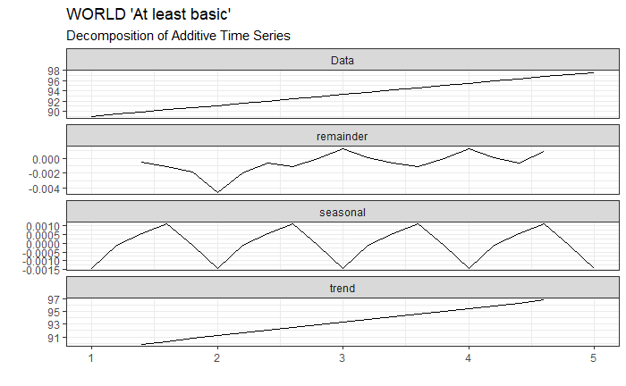

```r
library(ggplot2)
library(ggfortify)

autoplot(ddata_basic)+
  theme_bw()+
  labs(title = "WORLD 'At least basic'",
       subtitle = "Decomposition of Additive Time Series",
       xlab = "Time (freq=5 years)",
       ylab = "values")
```

It is obvious that the data has trend

## TS Forecasting

Several ways to do it:

- naive (moving average)
- exponential smoothing:
  - Simple (ses(); no trend/difference, no seasonality)
  - Holt’s (holt(); trend, no seasonality; can be additive or multiplicative)
  - Holt-winter’s (ets() or error-trend-seasonality, for trend and seasonality)
  - Dampened trend (not applicable for us)
- ARIMA

Naive is basically using the previous day value for today’s value. Not useful for us

Exponential smoothing is a step better as it the weight of recent values are greater than the older values. Each values/observations will have a weight/smoothing parameter ( α , β and γ ) and the future value is forecasted by exponential summation of weight * values across time. It is also pretty simple method so does not have high computational effort.

We can also tune the weight to minimize prediction error but it is not done in this project as we are displaying preliminary forecast of various different region. In holt method, it will automatically optimize the α , β and γ parameters by minimizing AIC and BIC values or errors of the training set (see summary forecast below).

Source: http://uc-r.github.io/ts_exp_smoothing

### Exponential Smoothing - ETS/holt-winter’s (not used)

Use state space model, source: https://towardsdatascience.com/a-guide-to-forecasting-in-r-6b0c9638c261

```r
#Can also Create samples but not enough dataset :(
# training=window(tseries_ts, start = 2000, end = 2015)
# validation=window(tseries_ts, start = 2016)
```

*Use ETS() and let it choose model type automatically*

Auto model means it will choose a type that minimize RMSE, AIC, and BIC

```r
#plot(forecast_ts_basic)
```

```r
library(forecast)
#library(MLmetrics)

ets_model = ets(forecast_ts_basic, allow.multiplicative.trend = TRUE)
  #allow multiplicative in case they found any multiplicative trend.
summary(ets_model)
```

```
ETS(A,A,N)

Call:
 ets(y = forecast_ts_basic, allow.multiplicative.trend = TRUE)

  Smoothing parameters:
    alpha = 0.9999
    beta  = 0.7514

  Initial states:
    l = 88.6397
    b = 0.4187

  sigma:  0.0035

      AIC      AICc       BIC
-167.5568 -163.5568 -162.3342

Training set error measures:
                       ME        RMSE        MAE          MPE        MAPE
Training set 0.0002040916 0.003183403 0.00119631 0.0002524968 0.001269552
                    MASE      ACF1
Training set 0.002807573 0.1089966
```

ETS(A,A,N) means the exponential smoothing model (ETS) has:

- error type “A” = additive (some data is “M” = multiplicative)
- trend type “A” = additive
- season type “N” = none.

As predicted before, the dataset only have additive trend with no seasonality.

RMSE (root mean squared error) is really low so the trend is quite good. The prediction accuracy (MAPE) is only 0.0012% though?

source: https://www.rdocumentation.org/packages/forecast/versions/8.21/topics/ets

https://rstudio-pubs-static.s3.amazonaws.com/681477_4af44c0abe0741d8ad5093df109130b5.html

```r
#library(ModelMetrics)
ets_forecast = forecast(ets_model, h=10)
ets_forecast
```

|  | Point Forecast | Lo 80 | Hi 80 | Lo 95 | Hi 95 |
| --- | --- | --- | --- | --- | --- |
| 2021 | 98.00247 | 97.99794 | 98.00701 | 97.99554 | 98.00941 |
| 2022 | 98.42443 | 98.41529 | 98.43358 | 98.41045 | 98.43842 |
| 2023 | 98.84639 | 98.83182 | 98.86096 | 98.82410 | 98.86868 |
| 2024 | 99.26835 | 99.24761 | 99.28909 | 99.23663 | 99.30007 |
| 2025 | 99.69031 | 99.66274 | 99.71788 | 99.64815 | 99.73247 |
| 2026 | 100.11227 | 100.07726 | 100.14727 | 100.05873 | 100.16580 |
| 2027 | 100.53423 | 100.49123 | 100.57723 | 100.46846 | 100.59999 |
| 2028 | 100.95618 | 100.90466 | 101.00771 | 100.87739 | 101.03498 |
| 2029 | 101.37814 | 101.31760 | 101.43868 | 101.28555 | 101.47073 |
| 2030 | 101.80010 | 101.73007 | 101.87013 | 101.69300 | 101.90720 |

```r
#paste("Validation RMSE: ", round(RMSE(validation, ets_forecast$mean),2))
```

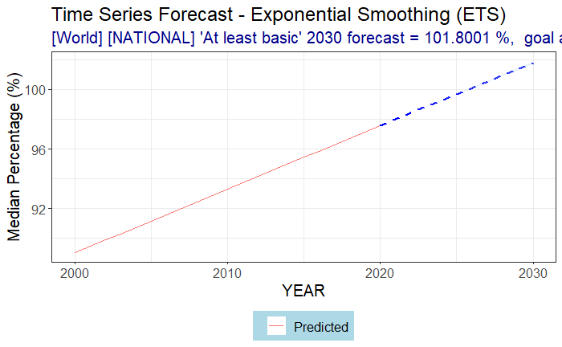

```r
target <- round(ets_forecast$mean[10], 4)
target_label <- "N/A"
if(target >= 100){
  target_label <- "goal achieved!"
} else {
  target_label <- "goal not achieved"
}

autoplot(ets_forecast, predict.size = 1,
         predict.colour = 'blue', predict.linetype = 'dashed',
         conf.int = TRUE, conf.int.fill = "lightblue")+
  autolayer(fitted(ets_model), series = "Predicted")+
  theme_bw()+
  theme(text=element_text(size=15))+
  expand_limits(y=100)+
  labs(title = "Time Series Forecast - Exponential Smoothing (ETS)",
       subtitle = paste("[World] [NATIONAL] 'At least basic' 2030 forecast =",
                       target, "%, ", target_label),
       x = "YEAR",
       y = "Median Percentage (%)")+
  guides(colour=guide_legend(title=""))+
    theme(legend.position = "bottom",
          legend.background = element_rect(fill="lightblue",linetype="solid"),
          plot.subtitle = element_text(color = "darkblue"))
```

### ES - (HOLT) with trend only

Holt is double exponential coefficient using alpha and beta. If those values are closer to 1, that means it is fast learning. If it is closer to 0, then it is slow learning. We are using the model as is so the alpha and beta coefficient is automatically chosen by the model. We can improve this by running an optimizer (loop within certain range of beta). However, since the plot is reactive, we will just leave it as is (auto value).

Source: https://www.geeksforgeeks.org/exponential-smoothing-in-r-programming/

```r
holt_forecast <- holt(forecast_ts_basic)
summary(holt_forecast)
```

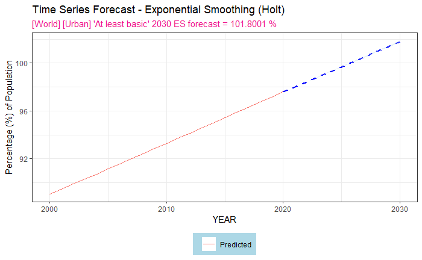

```r
# Use autoplot() to plot the forecasts
autoplot(holt_forecast, predict.size = 1,
         predict.colour = 'blue', predict.linetype = 'dashed',
         conf.int = TRUE, conf.int.fill = "lightblue") +
  autolayer(fitted(holt_forecast), series='Predicted') +
  theme_bw()+
  labs(title = "Time Series Forecast - Exponential Smoothing (Holt)",
       subtitle = paste("[World] [Urban] 'At least basic' 2030 ES forecast =",
                       round(holt_forecast$mean[10], 4), "%"),
       x = "YEAR",
       y = "Percentage (%) of Population")+
  guides(colour=guide_legend(title=""))+
  theme(legend.position = "bottom",
        legend.background = element_rect(fill="lightblue",linetype="solid"),
        plot.subtitle = element_text(color = "deeppink2"))
```

source: https://stackoverflow.com/questions/52997855/add-legend-entry-for-prediction-line-in-rs-forecast-package

### ARIMA

ARIMA: Auto-Regressive Integrated Moving Average

source: https://www.simplilearn.com/tutorials/data-science-tutorial/time-series-forecasting-in-r#GoTop

```r
model_arima <- auto.arima(forecast_ts_basic)
model_arima
```

```
Series: forecast_ts_basic
ARIMA(0,2,0)

sigma^2 = 0.000834:  log likelihood = 81.63
AIC=-161.26   AICc=-161.03   BIC=-160.32
```

ARIMA (p, d, q) = https://people.duke.edu/~rnau/411arim.htm

- p is the number of autoregressive terms,
- d is the number of nonseasonal differences needed for stationarity, and
- q is the number of lagged forecast errors in the prediction equation.

If it is (0, 1, 1) then it is ES.

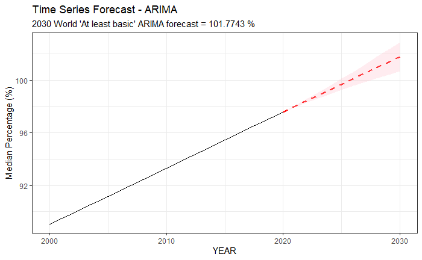

```r
#forecast the next 10 years using library(forecast)
model_arima_fc <- forecast(model_arima, level=c(95), h=10)

autoplot(model_arima_fc, predict.size = 1,
         predict.colour = 'red', predict.linetype = 'dashed',
         conf.int = TRUE, conf.int.fill = "pink",
         annotations=c("+", "predict"))+
  theme_bw()+
  expand_limits(y=100)+
  labs(title = "Time Series Forecast - ARIMA",
       subtitle = paste("2030 World 'At least basic' ARIMA forecast =",
                       round(model_arima_fc$mean[10], 4), "%"),
       x = "YEAR",
       y = "Median Percentage (%)")
```

##Question

How to resize the display autoplot? Increase font size?